# stat547_vectorization

Sirine

21/02/2020

# Vectorized operations : basics

## What is vectorization?

There are several ways of applying the same operation to all the elements of a given vector.

You can use a loop :

```r
x <- c(1, 2, 3, 4)
y <- c()

for (i in 1:length(x)){
  y[i] <- 2*x[i]
}
```

Can you guess the values of `y`?

```r
y
```

```
## [1] 2 4 6 8
```

But you can also use vectorized operations!

```r
x <- c(1, 2, 3, 4)

y <- 2*x
```

Can you guess the value of `y`?

```r
y
```

```
## [1] 2 4 6 8
```

You can also apply a different operation to each one of the values in a given vector. For example, we can sum the values of two vectors :

```r
x1 <- c(1, 2, 3, 4)
x2 <- c(10, 20, 30, 40)
y <- c()

for (i in 1:length(x1)){
  y[i] <- x1[i] + x2[i]
}
```

Can you guess the values of `y`?

```r
y
```

```
## [1] 11 22 33 44
```

Now, let’s do the same thing using vectorization :

```r
x1 <- c(1, 2, 3, 4)
x2 <- c(10, 20, 30, 40)

y <- x1 + x2
```

Can you guess the values of `y`?

```r
y
```

```
## [1] 11 22 33 44
```

## Why do we use vectorization?

Let’s come back to the first example we saw (multiply the values of a vector by 2), but let’s use a bigger vector this time :

```r
x <- 1:100000000
print(paste0('The length of x is ', length(x)))
```

```
## [1] "The length of x is 100000000"
```

Do you think the loop is going to be slower, faster, or will take the same time as the vectorized operation?

Let’s time the `for` loop!

```r
y <- c()

#start timming
tic()
for (i in 1:length(x)){
  y[i] <- 2*x[i]
}

#end timming
toc()
```

```
## 49.88 sec elapsed
```

Let’s take a look at the time taken by the vectorized operation now :

```r
#start timming
tic()

y <- 2*x

#end timming
toc()
```

```
## 0.8 sec elapsed
```

The vectorized operation is a lot faster than the `for` loop! It’s usually recommended to use vectorized operation rather than regular loops.

## Other vectorized operations

Here are a few examples of other operations that are vectorized.

- Check if the values of two vectors are the same :

```r
x1 <- c(1, 2, 3, 4)
x2 <- c(1, 2, 1, 2)

y <- x1 == x2
```

Can you guess the values of `y`?

```r
y
```

```
## [1]  TRUE  TRUE FALSE FALSE
```

- Compare the values of two vectors :

```r
x1 <- c(1, 2, 3, 4)
x2 <- c(1, 2, 1, 2)

y <- x1 > x2
```

Can you guess the values of `y`?

```r
y
```

```
## [1] FALSE FALSE  TRUE  TRUE
```

- Logical comparaisons can also be used:

```r
# compares each elements of each vector by position
y <- c(TRUE, TRUE, TRUE) & c(FALSE, TRUE, TRUE)
```

Can you guess the values of `y`?

```r
y
```

```
## [1] FALSE  TRUE  TRUE
```

There are a lot of other operations that are vectorized! Here is a list of vector operators : [R Operators cheat sheet](https://cran.r-project.org/doc/contrib/Baggott-refcard-v2.pdf)

# Functional programming using the `purrr` package

Until now, we have just applied simple operations to vectors. The functions were only applied to a single element of the vector, which were doubles. What if we want to use data frames? In this case, one “element” becomes a whole vector (a column of the data frame), and the functions have to accept a vector as an input.

Let’s now try to work with data frames. How do we apply a function to all the columns of a data frame?

We are going to work with the `iris` data frame :

```r
#select only the columns that represents a numerical variable
iris_df <- iris %>%
  select(-Species)

head(iris_df)
```

```
##   Sepal.Length Sepal.Width Petal.Length Petal.Width
## 1          5.1         3.5          1.4         0.2
## 2          4.9         3.0          1.4         0.2
## 3          4.7         3.2          1.3         0.2
## 4          4.6         3.1          1.5         0.2
## 5          5.0         3.6          1.4         0.2
## 6          5.4         3.9          1.7         0.4
```

Let’s compute the mean of each column :

```r
means <- vector("double", ncol(iris_df))

for (i in seq_along(iris_df)) {
    means[i] <- mean(iris_df[[i]], na.rm = TRUE)
}
```

`means` contains the means of each column :

```r
means
```

```
## [1] 5.843333 3.057333 3.758000 1.199333
```

We can do the same to find the minimum of each column :

```r
mins <- vector("double", ncol(iris_df))

for (i in seq_along(iris_df)) {
    mins[i] <- min(iris_df[[i]], na.rm = TRUE)
}
```

`mins` contains the minimums of each column :

```r
mins
```

```
## [1] 4.3 2.0 1.0 0.1
```

The two loops we just wrote seem to very similar to each other, we should try to write a function that takes the function we want to apply and a data frame as its inputs.

```r
my_function <- function(x, fun)  {
    value <- vector("double", ncol(x))
    for (i in seq_along(x)) {
        value[i] <- fun(x[[i]], na.rm = TRUE)
    }
    value
}
```

Let’s check if we find the same values as before :

```r
my_function(iris_df, mean)
```

```
## [1] 5.843333 3.057333 3.758000 1.199333
```

```r
my_function(iris_df, min)
```

```
## [1] 4.3 2.0 1.0 0.1
```

We find exactly the same values as when we were using the for loop!

The function `my_function` we wrote above uses basically the same idea as the `map_dbl` function from the `purrr` package. The only difference is that the `purrr` package is coded in C and uses the … for additional arguments.

*Note*: We have just written a functional, which is a function that takes another function as an input, and returns a vector as an output.

## The most general `purrr` function: `map`

The `purrr:map` function takes at least two arguments : a data frame and a function.

`map(.x, .f, ...)`

This means that we are going to apply the function `f` for every element of `x`.

This image may help you to better understand what does the `purrr:map` function do :

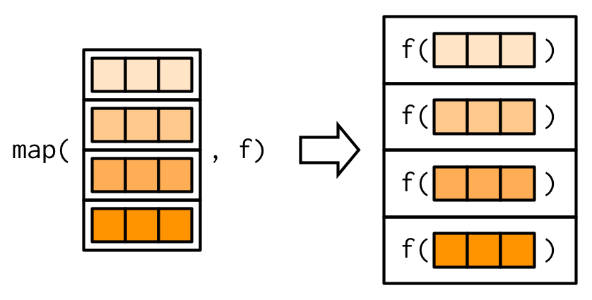

*Note* : in this image, the elements of the object that is used as an input seem to be the rows, but when we use a data frame as the input, they actually correspond to the columns of the data frame.

Let’s calculate the mean of the columns of the iris data frame :

```r
library(purrr)
map(iris_df, mean)
```

```
## $Sepal.Length
## [1] 5.843333
##
## $Sepal.Width
## [1] 3.057333
##
## $Petal.Length
## [1] 3.758
##
## $Petal.Width
## [1] 1.199333
```

The only difference with our `my_function` function we created above is that the output is a list! No, we are going to take a look at the other functions that exist in the `purrr` library.

## Use the right `purrr::map*` function based on your desired output

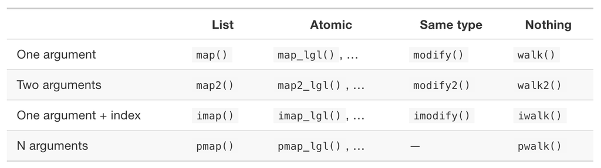

Source: Advanced R by Hadley Wickham

Let’s try to use the `purrr:map_dbl` function :

```r
library(purrr)
map_dbl(iris_df, mean)
```

```
## Sepal.Length  Sepal.Width Petal.Length  Petal.Width
##     5.843333     3.057333     3.758000     1.199333
```

This time, the output is a vector containing doubles! This is exactly what we had with the function we created.

What if we want to specify some arguments of our function (ignore the NAs when we compute the mean for instance)?

## Specify some arguments of the function

Let’s introduce some missing data in our data frame :

```r
iris_NA <- iris_df
iris_NA[1, 1] <- NA
```

What happens if we use `purrr:map_dbl`?

```r
map_dbl(iris_NA, mean)
```

```
## Sepal.Length  Sepal.Width Petal.Length  Petal.Width
##           NA     3.057333     3.758000     1.199333
```

The mean of the first column is now equal to NA. To solve this issue, we can use `na.rm = TRUE` as an argument of the `mean` function. But how do we add this to our `map_dbl` call?

We have to create what we call an anonymous function!

```r
map_dbl(iris_NA, function(df) mean(df, na.rm  = TRUE))
```

```
## Sepal.Length  Sepal.Width Petal.Length  Petal.Width
##     5.848322     3.057333     3.758000     1.199333
```

The general format of an anonymous function is `function(x) body of the function`. For example, if you want to compute $4^2$ using an anonymous function, it would be :

```r
(function(x) x**2)(4)
```

```
## [1] 16
```

The anonymous function is surrounded by round brackets, and so is the input of the anonymous function.

*Note* : There is a shorter way to write anonymous functions :

```r
map_dbl(iris_NA, ~ mean(., na.rm  = TRUE))
```

```
## Sepal.Length  Sepal.Width Petal.Length  Petal.Width
##     5.848322     3.057333     3.758000     1.199333
```

The `function(df)` is replaced by `~` and the argument of the function is replaced by a `.`.

## Mapping with two data object

So far, we have only used the `purrr:map` function that only takes one data object and one function as an argument. What if we want to do more complicated operations, that use a function that needs more than one input?

For example, how would you calculate the weighted means (using weighted.mean) of the columns of a given data frame, where the weights are in another data frame?

Let’s create a data frame that contains the weights :

```r
weights <- tibble(weight_sepal_legth = rpois(nrow(iris_NA), 3),
                 weight_sepal_width = rpois(nrow(iris_NA), 3),
                 weight_petal_legth = rpois(nrow(iris_NA), 3),
                 weight_petal_width = rpois(nrow(iris_NA), 3),)
```

First, let’s see what are the parameters of `weighted.mean`

```r
?weighted.mean
```

```
## starting httpd help server ... done
```

In order to know which `purrr:map*` function we have to use, let’s take a look at the following table :

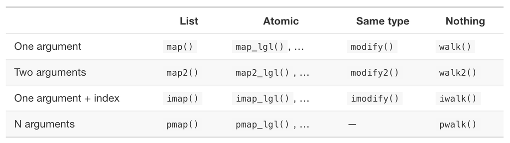

As we have two arguments, we should use the `purrr:map2*` function. As we want the output of the function to be a data frame, we are goint to use `purrr:map2_df`.

```r
map2_df(iris_NA, weights, weighted.mean)
```

```
## # A tibble: 1 x 4
##   Sepal.Length Sepal.Width Petal.Length Petal.Width
##          <dbl>       <dbl>        <dbl>       <dbl>
## 1           NA        3.07         3.85        1.23
```

We have the same issue as before because of the NAs… We have to use an anonymous function!

```r
map2_df(iris_NA, weights, function(x, y) weighted.mean(x, y, na.rm = TRUE))
```

```
## # A tibble: 1 x 4
##   Sepal.Length Sepal.Width Petal.Length Petal.Width
##          <dbl>       <dbl>        <dbl>       <dbl>
## 1         5.83        3.07         3.85        1.23
```

What would be the short form of this anonymous function?

```r
map2_df(iris_NA, weights, ~ weighted.mean(.x, .y, na.rm = TRUE))
```

```
## # A tibble: 1 x 4
##   Sepal.Length Sepal.Width Petal.Length Petal.Width
##          <dbl>       <dbl>        <dbl>       <dbl>
## 1         5.83        3.07         3.85        1.23
```

*Note* : if `y` has less elements than `x`, the elements of `y` will be used several times.

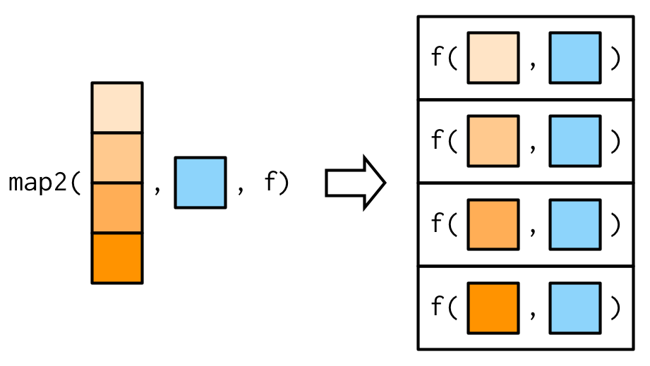

This is very useful when `y` has only one element.

## Mapping with more than two data object

When we have more than two arguments, we should use the `purrr:pmap*` function.

```r
f <-  function(x, y, z, arg = 0){
  (x+y+z)/3 + arg

}

pmap(list(c(1, 1), c(1, 2), c(1, 3)), f)
```

```
## [[1]]
## [1] 1
##
## [[2]]
## [1] 2
```

If we want to use an anonymous function, we have to us `..1, ..2, ..3`.

```r
pmap(list(c(1, 1), c(1, 2), c(1, 3)), ~ f(..1, ..2, ..3, arg=2))
```

```
## [[1]]
## [1] 3
##
## [[2]]
## [1] 4
```

*Note* : if you use `purrr:pmap*` on a single data frame, it will iterate row-wise!

```r
pmap(iris_df, ~ mean(.x)) %>%
  head()
```

```
## [[1]]
## [1] 5.1
##
## [[2]]
## [1] 4.9
##
## [[3]]
## [1] 4.7
##
## [[4]]
## [1] 4.6
##
## [[5]]
## [1] 5
##
## [[6]]
## [1] 5.4
```